# Informe diario de riesgo

Unidad de Inteligencia / SECOS

2024-12-25

Este documento, desarrollado en conjunto por la Unidad de Inteligencia, el Instituto SECOS y las Direcciones Regionales en el marco del Programa GEMM, ofrece un análisis actualizado de las actividades de pesca en caletas del Maule y los precios en el TPM. El objetivo es facilitar la toma de decisiones estratégicas y la activación de fiscalizaciones efectivas.

**Fuentes de Datos:**

- **Datos de precios y zarpes:** Recopilados diariamente de hojas de cálculo en línea gestionadas por las regiones.
- **Información meteorológica:** Es obtenida de APIs que proporcionan pronósticos actualizados cada hora, para complementar los análisis con las condiciones climáticas que impactan la pesca.
- **Datos de Desembarque y Fiscalización:** Recopilados diariamente de las bases de datos de SERNAPESCA.

**Autoactualización:** El informe se actualiza automáticamente cada hora mediante cron jobs, garantizando la relevancia de la información y demostrando el potencial de la tecnología para optimizar la gestión y monitoreo en tiempo real.

Este reporte es parte de una iniciativa en fase inicial y se espera que evolucione con el aporte de diversos actores de SERNAPESCA, refinando y validando continuamente los análisis presentados.

Estado de los Datos

Advertencia: Los datos no están actualizados al día de hoy. Los datos de precios son del 24 de December de 2024 y los datos de zarpe son del 24 de December de 2024 . Por favor, verifica la relevancia de este análisis para decisiones críticas.

Riesgo

Nivel de Alerta del Día: Bajo

Riesgo Bajo: No se detectan condiciones de riesgo significativas para la Merluza Común hoy.

Información del Clima

| Lugar | Fecha | Velocidad del viento (kph) | Período de oleaje (seg) | Dirección del viento | Altura de las olas (m) |
| --- | --- | --- | --- | --- | --- |
| ILOCA | 2024-12-25 | 16 | 9.1 | W | 0.6 |
| LICANTEN | 2024-12-25 | 16 | 9.1 | W | 0.6 |
| CONSTITUCION | 2024-12-25 | 12 | 9.2 | S | 0.6 |
| PELLUHUE | 2024-12-25 | 24 | 9.3 | SW | 0.7 |

Las condiciones meteorológicas podrían ser positivas para la pesca.

Desembarque Maule

Resumen Combinado de Desembarques y Declaraciones por Especie y Caleta (Ayer)

| Caleta | Especie | Total_Declaraciones | Total_Desembarque |
| --- | --- | --- | --- |
| CURANIPE | Reineta | 33 | 64.332 |
| DUAO | Jibia | 1 | 1.163 |
| DUAO | Reineta | 19 | 22.793 |
| MAGUILLINES | Jibia | 3 | 9.668 |
| MAGUILLINES | Reineta | 22 | 38.271 |

Zarpes Maule

Actividades de Zarpe para la última fecha registrada: 24 de December de 2024

| FECHA | CALETA | ZARPE | NUMERO_EMBARCACIONES | OBSERVACIONES |
| --- | --- | --- | --- | --- |
| 24 de December de 2024 | MAGUILLINES | NO | 0 | NA |
| 24 de December de 2024 | DUAO | NO | 0 | NA |
| 24 de December de 2024 | CURANIPE | NO | 0 | NA |

Total de Caletas en Riesgo: 0

Precios terminal Pesquero Metropolitano

Precios por especie para el 24 de December de 2024

| ESPECIE | PRECIO_CAJA |
| --- | --- |
| MERLUZA COMUN | 42500 |

No hay riesgo en el precio de la caja para MERLUZA COMUN - Valor actual: $ 42500

Operativos de Fiscalización

Tabla Resumen de Cometidos por Oficina

| Oficina | Cometidos_30_Dias | Cometidos_7_Dias | Cometidos_Ayer |
| --- | --- | --- | --- |
| CONSTITUCION | 6 | 0 | 0 |
| LICANTEN | 4 | 0 | 0 |
| PELLUHUE | 10 | 0 | 0 |

Gráfico de Precios Merluza Común TPM

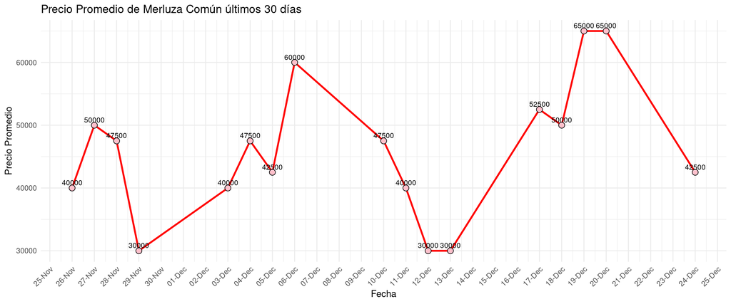